# Data607 - Tidyverse Create Assignment

Amit Kapoor

3/24/2020

### Assignment

Using one or more TidyVerse packages and any dataset from fivethirtyeight.com or Kaggle, the task is to create a programming sample “vignette” that demonstrates use of one or more of the capabilities of selected TidyVerse package.

### Getting started

Lets load tidyverse package first. It includes readr, dplyr, tidyr, ggplot2, stringr, tibble, forcats and purr packages.

- **tidyverse**

We’re going to load a dataset from [fivethirtyeight.com](https://fivethirtyeight.com/features/which-state-has-the-worst-drivers/) to help us show tidyverse package at work. This data shows America’s bad drivers in all the states, involved in collisions.

First step is to read the bad-drivers data from github repository. The data contains below fields:

- State
- Number of drivers involved in fatal collisions per billion miles
- Percentage Of Drivers Involved In Fatal Collisions Who Were Speeding
- Percentage Of Drivers Involved In Fatal Collisions Who Were Alcohol-Impaired
- Percentage Of Drivers Involved In Fatal Collisions Who Were Not Distracted
- Percentage Of Drivers Involved In Fatal Collisions Who Had Not Been Involved In Any Previous Accidents
- Car Insurance Premiums ($)
- Losses incurred by insurance companies for collisions per insured driver ($)

#### Data read using readr package

- **read_csv()** function is from **readr** package, used for reading flat file data with comma separated values.

```r
# define URL for bad drivers data
theURL <- 'https://raw.githubusercontent.com/fivethirtyeight/data/master/bad-drivers/bad-drivers.csv'

# read data
bad_drivers <- read_csv(theURL)
head(bad_drivers)
```

```
## # A tibble: 6 x 8
##   State `Number of driv… `Percentage Of … `Percentage Of … `Percentage Of …
##   <chr>            <dbl>            <dbl>            <dbl>            <dbl>
## 1 Alab…             18.8               39               30               96
## 2 Alas…             18.1               41               25               90
## 3 Ariz…             18.6               35               28               84
## 4 Arka…             22.4               18               26               94
## 5 Cali…             12                 35               28               91
## 6 Colo…             13.6               37               28               79
## # … with 3 more variables: `Percentage Of Drivers Involved In Fatal Collisions
## #   Who Had Not Been Involved In Any Previous Accidents` <dbl>, `Car Insurance
## #   Premiums ($)` <dbl>, `Losses incurred by insurance companies for collisions
## #   per insured driver ($)` <dbl>
```

In the next, we rename columns to replace big column names with shorter names.

- **glimpse()** function is from **tibble** package, used to see every column in a data frame.

```r
# rename columns
colnames(bad_drivers) <- c("STATE",
                           "DRIVERS_INVOLVED",
                           "PERC_DRIVERS_SPEED",
                           "PERC_DRIVERS_ALCHO",
                           "PERC_DRIVERS_NOT_DIST",
                           "PERC_DRIVERS_NO_ACC",
                           "INS_PREM",
                           "LOSS_INSCOMP")

glimpse(bad_drivers)
```

```
## Observations: 51
## Variables: 8
## $ STATE                 <chr> "Alabama", "Alaska", "Arizona", "Arkansas", "Ca…
## $ DRIVERS_INVOLVED      <dbl> 18.8, 18.1, 18.6, 22.4, 12.0, 13.6, 10.8, 16.2,…
## $ PERC_DRIVERS_SPEED    <dbl> 39, 41, 35, 18, 35, 37, 46, 38, 34, 21, 19, 54,…
## $ PERC_DRIVERS_ALCHO    <dbl> 30, 25, 28, 26, 28, 28, 36, 30, 27, 29, 25, 41,…
## $ PERC_DRIVERS_NOT_DIST <dbl> 96, 90, 84, 94, 91, 79, 87, 87, 100, 92, 95, 82…
## $ PERC_DRIVERS_NO_ACC   <dbl> 80, 94, 96, 95, 89, 95, 82, 99, 100, 94, 93, 87…
## $ INS_PREM              <dbl> 784.55, 1053.48, 899.47, 827.34, 878.41, 835.50…
## $ LOSS_INSCOMP          <dbl> 145.08, 133.93, 110.35, 142.39, 165.63, 139.91,…
```

#### Data wrangling/visualization using dplyr, tidyr and ggplot2 packages

As we must have noticed columns PERC_DRIVERS_SPEED, PERC_DRIVERS_ALCHO, PERC_DRIVERS_NOT_DIST, PERC_DRIVERS_NO_ACC are percentages of DRIVERS_INVOLVED. In the next step we will mutate new columns DRIVERS_SPEED, DRIVERS_ALCHO, DRIVERS_NOT_DIST, DRIVERS_NO_ACC by taking the given percentage of DRIVERS_INVOLVED column.

- **mutate()** function is from **dplyr** package, adds new variables and preserves existing ones.

```r
# create new column DRIVERS_SPEED which will be (DRIVERS_INVOLVED*PERC_DRIVERS_SPEED)/100
bad_drivers <- bad_drivers %>%
  mutate(DRIVERS_SPEED=(DRIVERS_INVOLVED*PERC_DRIVERS_SPEED)/100) %>%
  mutate(DRIVERS_ALCHO=(DRIVERS_INVOLVED*PERC_DRIVERS_ALCHO)/100) %>%
  mutate(DRIVERS_NOT_DIST=(DRIVERS_INVOLVED*PERC_DRIVERS_NOT_DIST)/100) %>%
  mutate(DRIVERS_NO_ACC=(DRIVERS_INVOLVED*PERC_DRIVERS_NO_ACC)/100)

glimpse(bad_drivers)
```

```
## Observations: 51
## Variables: 12
## $ STATE                 <chr> "Alabama", "Alaska", "Arizona", "Arkansas", "Ca…
## $ DRIVERS_INVOLVED      <dbl> 18.8, 18.1, 18.6, 22.4, 12.0, 13.6, 10.8, 16.2,…
## $ PERC_DRIVERS_SPEED    <dbl> 39, 41, 35, 18, 35, 37, 46, 38, 34, 21, 19, 54,…
## $ PERC_DRIVERS_ALCHO    <dbl> 30, 25, 28, 26, 28, 28, 36, 30, 27, 29, 25, 41,…
## $ PERC_DRIVERS_NOT_DIST <dbl> 96, 90, 84, 94, 91, 79, 87, 87, 100, 92, 95, 82…
## $ PERC_DRIVERS_NO_ACC   <dbl> 80, 94, 96, 95, 89, 95, 82, 99, 100, 94, 93, 87…
## $ INS_PREM              <dbl> 784.55, 1053.48, 899.47, 827.34, 878.41, 835.50…
## $ LOSS_INSCOMP          <dbl> 145.08, 133.93, 110.35, 142.39, 165.63, 139.91,…
## $ DRIVERS_SPEED         <dbl> 7.332, 7.421, 6.510, 4.032, 4.200, 5.032, 4.968…
## $ DRIVERS_ALCHO         <dbl> 5.640, 4.525, 5.208, 5.824, 3.360, 3.808, 3.888…
## $ DRIVERS_NOT_DIST      <dbl> 18.048, 16.290, 15.624, 21.056, 10.920, 10.744,…
## $ DRIVERS_NO_ACC        <dbl> 15.040, 17.014, 17.856, 21.280, 10.680, 12.920,…
```

In this step we will draw a stacked bar lot using ggplot() method having states on X axis and DRIVERS_SPEED and DRIVERS_INVOLVED stacked together on Y axis. To achive this we first used select() method to get required columns. The used gather() method to make data long for DRIVERS_INVOLVED and DRIVERS_SPEED and finally used ggplot() to draw stacked bar plot.

- **select()** function is from **dplyr** package that keeps only the variables we mention.
- **gather()** function is from **tidyr** package that takes multiple columns and collapses into key-value pairs, duplicating all other columns as needed.
- **ggplot()** All **ggplot2** plots begin with a call to ggplot().

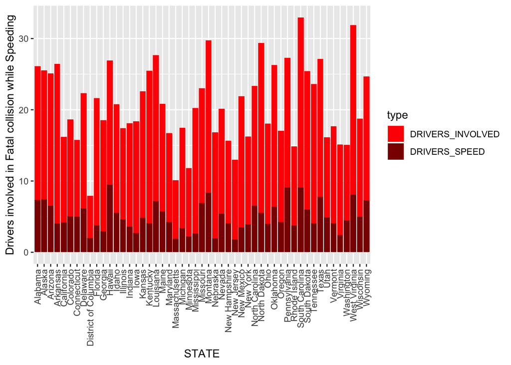

```r
bad_drivers %>%
  select(STATE, DRIVERS_INVOLVED, DRIVERS_SPEED) %>%
  gather(type, value, DRIVERS_INVOLVED:DRIVERS_SPEED) %>%
  ggplot(., aes(x = STATE,y = value, fill = type)) +
  geom_bar(position = "stack", stat="identity") +
  scale_fill_manual(values = c("red", "darkred")) +
  ylab("Drivers involved in Fatal collision while Speeding") +
  theme(axis.text.x=element_text(angle=90,hjust=1,vjust=0.5))
```

Similarly next stacked plot is having states on X axis and DRIVERS_ALCHO and DRIVERS_INVOLVED stacked together on Y axis. To achive this we first used select() method to get required columns. The used gather() method to make data long for DRIVERS_INVOLVED and DRIVERS_ALCHO and finally used ggplot() to draw stacked bar plot.

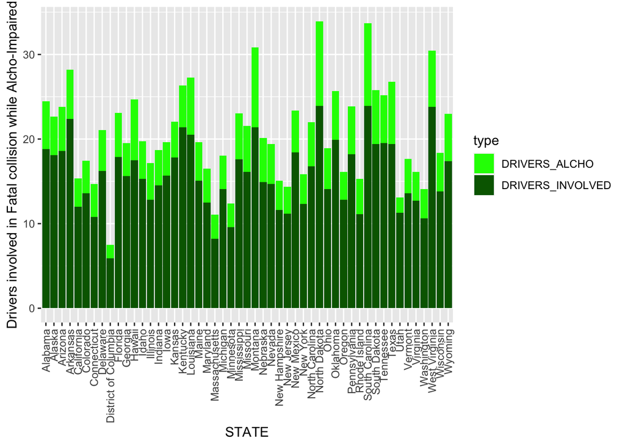

```r
bad_drivers %>%
  select(STATE, DRIVERS_INVOLVED, DRIVERS_ALCHO) %>%
  gather(type, value, DRIVERS_INVOLVED:DRIVERS_ALCHO) %>%
  ggplot(., aes(x = STATE,y = value, fill = type)) +
  geom_bar(position = "stack", stat="identity") +
  scale_fill_manual(values = c("green", "darkgreen")) +
  ylab("Drivers involved in Fatal collision while Alcho-Impaired") +
  theme(axis.text.x=element_text(angle=90,hjust=1,vjust=0.5))
```

Next stacked plot is having states on X axis and DRIVERS_NOT_DIST and DRIVERS_INVOLVED stacked together on Y axis. To achive this we first used select() method to get required columns. The used gather() method to make data long for DRIVERS_INVOLVED and DRIVERS_NOT_DIST and finally used ggplot() to draw stacked bar plot.

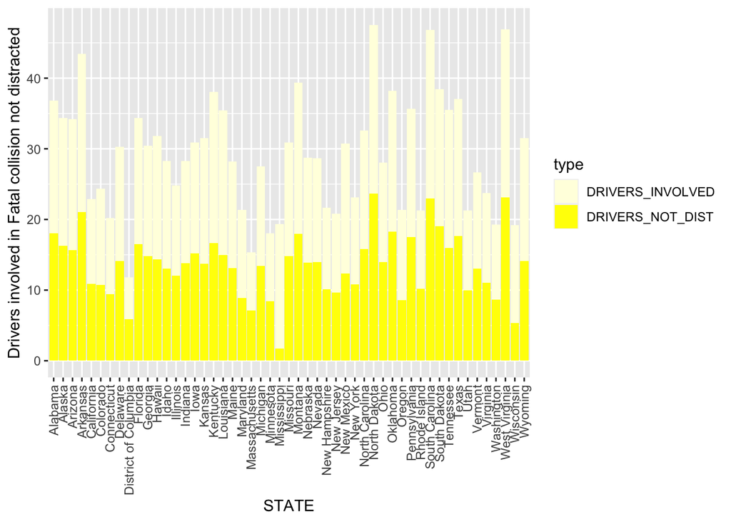

```r
bad_drivers %>%
  select(STATE, DRIVERS_INVOLVED, DRIVERS_NOT_DIST) %>%
  gather(type, value, DRIVERS_INVOLVED:DRIVERS_NOT_DIST) %>%
  ggplot(., aes(x = STATE,y = value, fill = type)) +
  geom_bar(position = "stack", stat="identity") +
  scale_fill_manual(values = c("lightyellow", "yellow")) +
  ylab("Drivers involved in Fatal collision not distracted") +
  theme(axis.text.x=element_text(angle=90,hjust=1,vjust=0.5))
```

Next stacked plot is having states on X axis and DRIVERS_NO_ACC and DRIVERS_INVOLVED stacked together on Y axis. To achive this we first used select() method to get required columns. The used gather() method to make data long for DRIVERS_INVOLVED and DRIVERS_NO_ACC and finally used ggplot() to draw stacked bar plot.

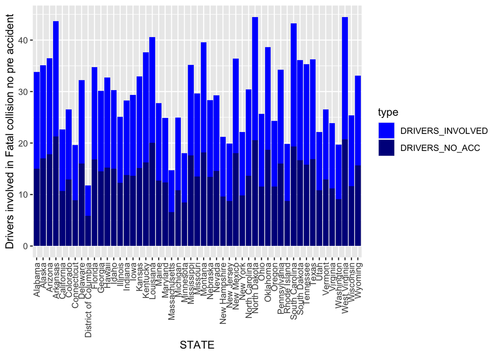

```r
bad_drivers %>%
  select(STATE, DRIVERS_INVOLVED, DRIVERS_NO_ACC) %>%
  gather(type, value, DRIVERS_INVOLVED:DRIVERS_NO_ACC) %>%
  ggplot(., aes(x = STATE,y = value, fill = type)) +
  geom_bar(position = "stack", stat="identity") +
  scale_fill_manual(values = c("blue", "darkblue")) +
  ylab("Drivers involved in Fatal collision no pre accident") +
  theme(axis.text.x=element_text(angle=90,hjust=1,vjust=0.5))
```

Below plot of for STATE vs INS_PREMIUM that used ggplot() method to draw a bar plot.

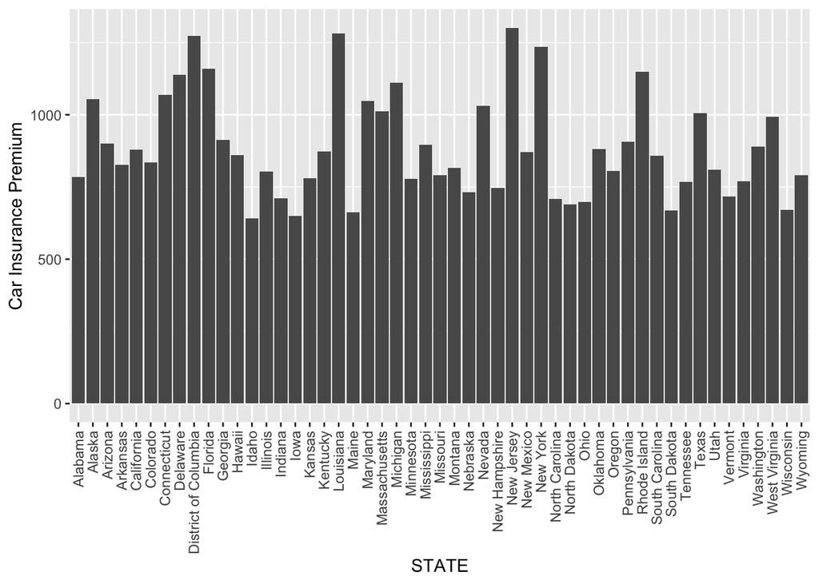

```r
bad_drivers %>%
  ggplot(., aes(x = STATE,y = INS_PREM)) +
  geom_bar(position = "stack", stat="identity") +
  ylab("Car Insurance Premium") +
  theme(axis.text.x=element_text(angle=90,hjust=1,vjust=0.5))
```

### **Conclusion**

Here we discussed various packages and their functions to explore bad drivers dataset. For complete set details refer (https://www.tidyverse.org/).

**Resources:**

- https://www.tidyverse.org/packages/
- https://fivethirtyeight.com/features/which-state-has-the-worst-drivers/